# Analysis of Global Terrorism Database with Washington Post ideology categorizations

Andrew Ba Tran

11/2/2018

### Context

This analysis is based on the [Global Terrorism Database](https://www.start.umd.edu/gtd/) paired with ideology categorizations as determined by The Washington Post for incidents between 2002 and 2018.

This supplementary data is inspired by Miller, Erin, 2017, “Global Terrorism Database Ideological Motivations of Terrorism in the United States”, and originally hosted at [Harvard Dataverse](https://dataverse.harvard.edu/dataset.xhtml?persistentId=doi:10.7910/DVN/SACQNK).

It is a supplemental file that adds categories to all the incidents tracked by the [GTD](https://www.start.umd.edu/gtd/), such as Environmental extremism, Left-wing extremism, Right-wing extremism, Religious extremism, etc. An analysis based on their categorizations can be found [here](http://wpinvestigative.github.io/global_terrorism_database_analysis/rmd/expl_analysis.html)

Visit the [repo for this project](http://www.github.com/wpinvestigative/global_terrorism_database_analysis) for more information/data.

```r
# replace NAs with blanks when displaying data in the markdown table
options(knitr.kable.NA = '')

library(tidyverse)
library(readxl)
library(knitr)

# We cannot rehost GTD's raw data files as per their Terms of Agreement
# If you're looking to reproduce our work, there are some extra steps
# It requires downloading their data and placing it into the `raw_data` folder in this project folder

# Load Raw Data -- instructions
# Download the raw data files from GTD

raw1 <- read_excel("../raw_data/gtd_70to95_0718dist.xlsx", sheet=1)
raw2 <- read_excel("../raw_data/gtd_96to13_0718dist.xlsx", sheet=1)
raw3 <- read_excel("../raw_data/gtd_14to17_0718dist.xlsx", sheet=1)
raw4 <- read_excel("../raw_data/gtd1993_0718dist.xlsx", sheet=1)
rawData <- rbind(raw1, raw2, raw3, raw4)

# Loading in the Post categorizations
df2002 <- read_csv("../raw_data/post_ideology_categorization.csv")

# Joining and summarizing by fatalities and incidents
summary <- df2002 %>%
  inner_join(rawData) %>%
  group_by(category, iyear) %>%
  summarize(fatalities=sum(nkill, na.rm=T), incidents=n())

# Some extra calculations to populate the text with in the markdown file

fig1 <- summary %>% filter(category=="right-wing" & iyear==2017)
fig1 <- fig1$incidents

fig2 <- summary %>% filter(category=="islamist extremism" & iyear==2017)
fig2 <- fig2$incidents

fig3 <- summary %>% filter(category=="left-wing" & iyear==2017)
fig3 <- fig3$incidents

fig4 <- summary %>% filter(category=="other/unknown" & iyear==2017)
fig4 <- fig4$incidents

fig5 <- round(fig1/(fig1+fig2+fig3+fig4)*100,0)

fig6 <- summary %>% filter(category=="right-wing" & iyear==2017)
fig6 <- fig6$fatalities

fig7 <- summary %>% filter(category=="right-wing" & iyear==2016)
fig7 <- fig7$incidents

fig8 <- round((fig1-fig7)/fig7*100,2)

s2010 <- summary %>% filter(iyear>=2010) %>% group_by(category) %>% summarize(fatalities=sum(fatalities, na.rm=T), incidents=sum(incidents, na.rm=T)) %>% mutate(percent_incidents=round(incidents/sum(incidents)*100,0), percent_fatalities=round(fatalities/sum(fatalities)*100,0)) %>% arrange(category)
```

### Analysis

Terrorist attacks in the United States have been in decline since 1970 when there were nearly 500 attacks recorded by the Global Terrorism Database from the University of Maryland. But since the lowest point of terrorist attacks in 2006 when there were only six recorded, the number has grown steadily to 10 times that amount in 2016 and 2017.

The number of fatalities have also spiked to 95 in 2017.

Though political ads and talk show hosts have emphasized left-wing violence from mobs and Antifa, an analysis by the Washington Post shows that the bulk of all attacks have been from suspects expressing right-wing beliefs such as anti-government and racist viewpoints.

In 2017 alone, there were 36 terrorist attacks from Right-wing suspects compared to 7 from Islamic extremists, and 10 from Left-wing suspects. About 55 percent of the attacks were from right-wing suspects, making up 11 total fatalities.

That’s a notable increase from 2016 of 350 percent, when there were only 8 incidents.

In 2018, there are already six incidents that have been preliminarily identified as right-wing attacks that have resulted in 18 deaths, according to researchers who maintain the United States Extremist Crime Database. These figures include the shooter who posted anti-Semitic conspiracy rants on a social media site moments before entering a synagogue in Pittsburgh and killing 11 people.

There is only one early possibility of a far-left attack in Georgia, in which a police officer was killed.

## Incidents in the U.S. since 1970

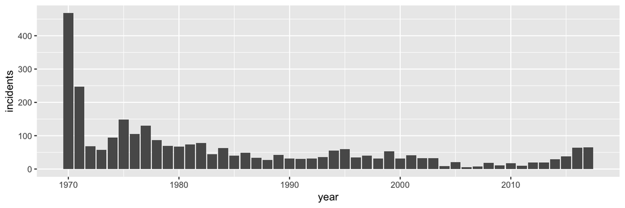

```r
i_total_by_year <- rawData %>% group_by(iyear) %>%
  filter(country_txt=="United States") %>%
  summarize(incidents=n())  %>%
  select(year=iyear, incidents)

write.csv(i_total_by_year, "../output_data/incidents_since_1970.csv", row.names=F, na="")

i_total_by_year %>% ggplot() +
  aes(x=year, y=incidents) +
  geom_bar(stat="identity")
```

## Incidents since 2002

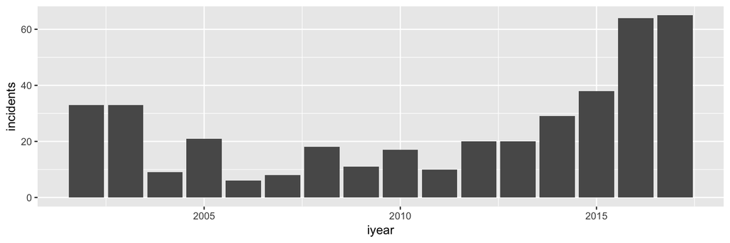

```r
i_since_2002 <- df2002 %>%
  inner_join(rawData) %>%
  group_by(iyear) %>%
  summarize(fatalities=sum(nkill, na.rm=T), incidents=n())

write.csv(i_since_2002, "../output_data/incidents_since_2002.csv", row.names=F, na="")

  i_since_2002 %>% ggplot() +
  aes(x=iyear, y=incidents) +
  geom_bar(stat="identity")
```

## Fatalities since 2002

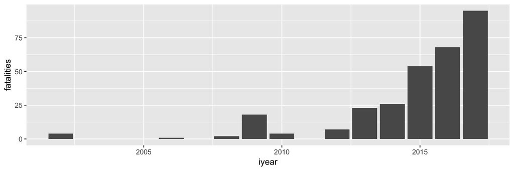

```r
f_since_2002 <- df2002 %>%
  inner_join(rawData) %>%
  group_by(iyear) %>%
  summarize(fatalities=sum(nkill, na.rm=T), incidents=n())

write.csv(f_since_2002, "../output_data/fatalities_since_2002.csv", row.names=F, na="")

  f_since_2002 %>%  ggplot() +
  aes(x=iyear, y=fatalities) +
  geom_bar(stat="identity")
```

## Incidents since 2002 by ideology

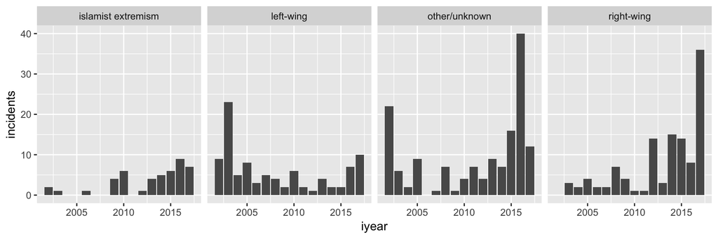

```r
df2002 %>%
  inner_join(rawData) %>%
  group_by(category, iyear) %>%
  summarize(fatalities=sum(nkill, na.rm=T), incidents=n()) %>%
  filter(iyear>2001) %>%
  ggplot() +
  aes(x=iyear, y=incidents) +
  geom_bar(stat="identity") +
  facet_wrap(~category, ncol=4)
```

```r
df2002 %>%
  inner_join(rawData) %>%
  group_by(category, iyear) %>%
  summarize(incidents=n()) %>%
  filter(iyear>2001) %>%
  spread(iyear, incidents) -> i_ideology

write.csv(i_ideology, "../output_data/incidents_since_2002_ideology.csv", row.names=F, na="")

kable(i_ideology)
```

| category | 2002 | 2003 | 2004 | 2005 | 2006 | 2007 | 2008 | 2009 | 2010 | 2011 | 2012 | 2013 | 2014 | 2015 | 2016 | 2017 |
| --- | --- | --- | --- | --- | --- | --- | --- | --- | --- | --- | --- | --- | --- | --- | --- | --- |
| islamist extremism | 2 | 1 |  |  | 1 |  |  | 4 | 6 |  | 1 | 4 | 5 | 6 | 9 | 7 |
| left-wing | 9 | 23 | 5 | 8 | 3 | 5 | 4 | 2 | 6 | 2 | 1 | 4 | 2 | 2 | 7 | 10 |
| other/unknown | 22 | 6 | 2 | 9 |  | 1 | 7 | 1 | 4 | 7 | 4 | 9 | 7 | 16 | 40 | 12 |
| right-wing |  | 3 | 2 | 4 | 2 | 2 | 7 | 4 | 1 | 1 | 14 | 3 | 15 | 14 | 8 | 36 |

## Fatalities since 2002 by ideology

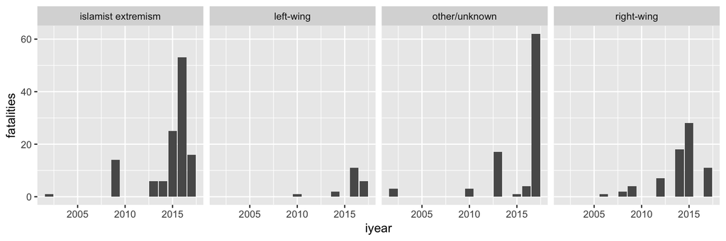

```r
df2002 %>%
  inner_join(rawData) %>%
  group_by(category, iyear) %>%
  summarize(fatalities=sum(nkill, na.rm=T), incidents=n()) %>%
  filter(iyear>2001) %>%
  ggplot() +
  aes(x=iyear, y=fatalities) +
  geom_bar(stat="identity") +
  facet_wrap(~category, ncol=4)
```

```r
df2002 %>%
  inner_join(rawData) %>%
  group_by(category, iyear) %>%
  summarize(fatalities=sum(nkill, na.rm=T)) %>%
  filter(iyear>2001) %>%
  spread(iyear, fatalities) -> f_fatalities

write.csv(f_fatalities, "../output_data/fatalities_since_2002_ideology.csv", row.names=F, na="")

kable(f_fatalities)
```

| category | 2002 | 2003 | 2004 | 2005 | 2006 | 2007 | 2008 | 2009 | 2010 | 2011 | 2012 | 2013 | 2014 | 2015 | 2016 | 2017 |
| --- | --- | --- | --- | --- | --- | --- | --- | --- | --- | --- | --- | --- | --- | --- | --- | --- |
| islamist extremism | 1 | 0 |  |  | 0 |  |  | 14 | 0 |  | 0 | 6 | 6 | 25 | 53 | 16 |
| left-wing | 0 | 0 | 0 | 0 | 0 | 0 | 0 | 0 | 1 | 0 | 0 | 0 | 2 | 0 | 11 | 6 |
| other/unknown | 3 | 0 | 0 | 0 |  | 0 | 0 | 0 | 3 | 0 | 0 | 17 | 0 | 1 | 4 | 62 |
| right-wing |  | 0 | 0 | 0 | 1 | 0 | 2 | 4 | 0 | 0 | 7 | 0 | 18 | 28 | 0 | 11 |

## Average fatalities by incident since 2002 by ideology

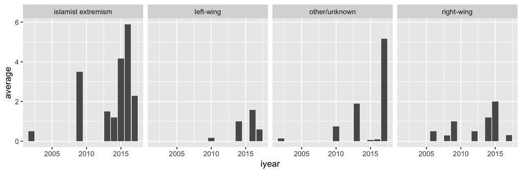

```r
df2002 %>%
  inner_join(rawData) %>%
  group_by(category, iyear) %>%
  summarize(fatalities=sum(nkill, na.rm=T), incidents=n()) %>%
  mutate(average=round(fatalities/incidents,2)) %>%
  filter(iyear>2001) %>%
  ggplot() +
  aes(x=iyear, y=average) +
  geom_bar(stat="identity") +
  facet_wrap(~category, ncol=4)
```

## Incidents since 2002 by group

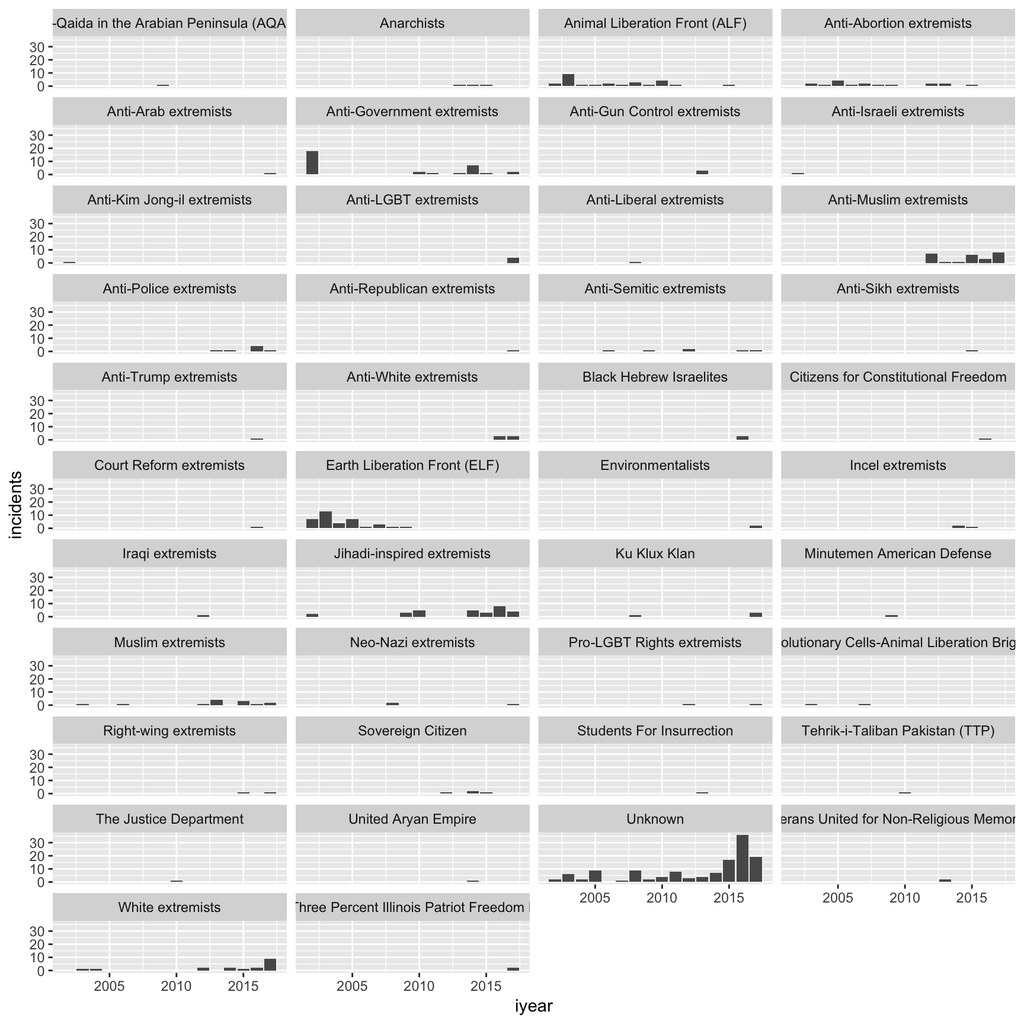

```r
df2002 %>%
  inner_join(rawData) %>%
  group_by(gname, iyear) %>%
  summarize(fatalities=sum(nkill, na.rm=T), incidents=n()) %>%
  filter(iyear>2001) %>%
  ggplot() +
  aes(x=iyear, y=incidents) +
  geom_bar(stat="identity") +
  facet_wrap(~gname, ncol=4)
```

```r
df2002 %>%
  inner_join(rawData) %>%
  group_by(gname, iyear) %>%
  summarize(incidents=n()) %>%
  filter(iyear>2001) %>%
  spread(iyear, incidents) -> i_group

write.csv(i_group, "../output_data/incidents_since_2002_group.csv", row.names=F, na="")

kable(i_group)
```

| gname | 2002 | 2003 | 2004 | 2005 | 2006 | 2007 | 2008 | 2009 | 2010 | 2011 | 2012 | 2013 | 2014 | 2015 | 2016 | 2017 |
| --- | --- | --- | --- | --- | --- | --- | --- | --- | --- | --- | --- | --- | --- | --- | --- | --- |
| Al-Qaida in the Arabian Peninsula (AQAP) |  |  |  |  |  |  |  | 1 |  |  |  |  |  |  |  |  |
| Anarchists |  |  |  |  |  |  |  |  |  |  |  | 1 | 1 | 1 |  |  |
| Animal Liberation Front (ALF) | 2 | 9 | 1 | 1 | 2 | 1 | 3 | 1 | 4 | 1 |  |  |  | 1 |  |  |
| Anti-Abortion extremists |  | 2 | 1 | 4 | 1 | 2 | 1 | 1 |  |  | 2 | 2 |  | 1 |  |  |
| Anti-Arab extremists |  |  |  |  |  |  |  |  |  |  |  |  |  |  |  | 1 |
| Anti-Government extremists | 18 |  |  |  |  |  |  |  | 2 | 1 |  | 1 | 7 | 1 |  | 2 |
| Anti-Gun Control extremists |  |  |  |  |  |  |  |  |  |  |  | 3 |  |  |  |  |
| Anti-Israeli extremists | 1 |  |  |  |  |  |  |  |  |  |  |  |  |  |  |  |
| Anti-Kim Jong-il extremists | 1 |  |  |  |  |  |  |  |  |  |  |  |  |  |  |  |
| Anti-LGBT extremists |  |  |  |  |  |  |  |  |  |  |  |  |  |  |  | 4 |
| Anti-Liberal extremists |  |  |  |  |  |  | 1 |  |  |  |  |  |  |  |  |  |
| Anti-Muslim extremists |  |  |  |  |  |  |  |  |  |  | 7 | 1 | 1 | 6 | 3 | 8 |
| Anti-Police extremists |  |  |  |  |  |  |  |  |  |  |  | 1 | 1 |  | 4 | 1 |
| Anti-Republican extremists |  |  |  |  |  |  |  |  |  |  |  |  |  |  |  | 1 |
| Anti-Semitic extremists |  |  |  |  | 1 |  |  | 1 |  |  | 2 |  |  |  | 1 | 1 |
| Anti-Sikh extremists |  |  |  |  |  |  |  |  |  |  |  |  |  | 1 |  |  |
| Anti-Trump extremists |  |  |  |  |  |  |  |  |  |  |  |  |  |  | 1 |  |
| Anti-White extremists |  |  |  |  |  |  |  |  |  |  |  |  |  |  | 3 | 3 |
| Black Hebrew Israelites |  |  |  |  |  |  |  |  |  |  |  |  |  |  | 3 |  |
| Citizens for Constitutional Freedom |  |  |  |  |  |  |  |  |  |  |  |  |  |  | 1 |  |
| Court Reform extremists |  |  |  |  |  |  |  |  |  |  |  |  |  |  | 1 |  |
| Earth Liberation Front (ELF) | 7 | 13 | 4 | 7 | 1 | 3 | 1 | 1 |  |  |  |  |  |  |  |  |
| Environmentalists |  |  |  |  |  |  |  |  |  |  |  |  |  |  |  | 2 |
| Incel extremists |  |  |  |  |  |  |  |  |  |  |  |  | 2 | 1 |  |  |
| Iraqi extremists |  |  |  |  |  |  |  |  |  |  | 1 |  |  |  |  |  |
| Jihadi-inspired extremists | 2 |  |  |  |  |  |  | 3 | 5 |  |  |  | 5 | 3 | 8 | 4 |
| Ku Klux Klan |  |  |  |  |  |  | 1 |  |  |  |  |  |  |  |  | 3 |
| Minutemen American Defense |  |  |  |  |  |  |  | 1 |  |  |  |  |  |  |  |  |
| Muslim extremists |  | 1 |  |  | 1 |  |  |  |  |  | 1 | 4 |  | 3 | 1 | 2 |
| Neo-Nazi extremists |  |  |  |  |  |  | 2 |  |  |  |  |  |  |  |  | 1 |
| Pro-LGBT Rights extremists |  |  |  |  |  |  |  |  |  |  | 1 |  |  |  |  | 1 |
| Revolutionary Cells-Animal Liberation Brigade |  | 1 |  |  |  | 1 |  |  |  |  |  |  |  |  |  |  |
| Right-wing extremists |  |  |  |  |  |  |  |  |  |  |  |  |  | 1 |  | 1 |
| Sovereign Citizen |  |  |  |  |  |  |  |  |  |  | 1 |  | 2 | 1 |  |  |
| Students For Insurrection |  |  |  |  |  |  |  |  |  |  |  | 1 |  |  |  |  |
| Tehrik-i-Taliban Pakistan (TTP) |  |  |  |  |  |  |  |  | 1 |  |  |  |  |  |  |  |
| The Justice Department |  |  |  |  |  |  |  |  | 1 |  |  |  |  |  |  |  |
| United Aryan Empire |  |  |  |  |  |  |  |  |  |  |  |  | 1 |  |  |  |
| Unknown | 2 | 6 | 2 | 9 |  | 1 | 9 | 2 | 4 | 8 | 3 | 4 | 7 | 17 | 36 | 19 |
| Veterans United for Non-Religious Memorials |  |  |  |  |  |  |  |  |  |  |  | 2 |  |  |  |  |
| White extremists |  | 1 | 1 |  |  |  |  |  |  |  | 2 |  | 2 | 1 | 2 | 9 |
| White Rabbit Three Percent Illinois Patriot Freedom Fighters Militia |  |  |  |  |  |  |  |  |  |  |  |  |  |  |  | 2 |

## Fatalities since 2002 by group

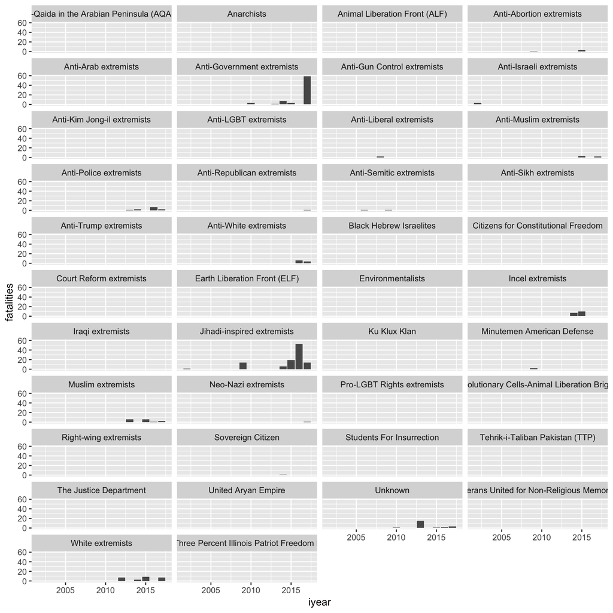

```r
df2002 %>%
  inner_join(rawData) %>%
  group_by(gname, iyear) %>%
  summarize(fatalities=sum(nkill, na.rm=T), incidents=n()) %>%
  filter(iyear>2001) %>%
  ggplot() +
  aes(x=iyear, y=fatalities) +
  geom_bar(stat="identity") +
  facet_wrap(~gname, ncol=4)
```

```r
df2002 %>%
  inner_join(rawData) %>%
  group_by(gname, iyear) %>%
  summarize(fatalities=sum(nkill, na.rm=T)) %>%
  filter(iyear>2001) %>%
  spread(iyear, fatalities) -> f_group

write.csv(f_group, "../output_data/fatalities_since_2002_group.csv", row.names=F, na="")

kable(f_group)
```

| gname | 2002 | 2003 | 2004 | 2005 | 2006 | 2007 | 2008 | 2009 | 2010 | 2011 | 2012 | 2013 | 2014 | 2015 | 2016 | 2017 |
| --- | --- | --- | --- | --- | --- | --- | --- | --- | --- | --- | --- | --- | --- | --- | --- | --- |
| Al-Qaida in the Arabian Peninsula (AQAP) |  |  |  |  |  |  |  | 0 |  |  |  |  |  |  |  |  |
| Anarchists |  |  |  |  |  |  |  |  |  |  |  | 0 | 0 | 0 |  |  |
| Animal Liberation Front (ALF) | 0 | 0 | 0 | 0 | 0 | 0 | 0 | 0 | 0 | 0 |  |  |  | 0 |  |  |
| Anti-Abortion extremists |  | 0 | 0 | 0 | 0 | 0 | 0 | 1 |  |  | 0 | 0 |  | 3 |  |  |
| Anti-Arab extremists |  |  |  |  |  |  |  |  |  |  |  |  |  |  |  | 0 |
| Anti-Government extremists | 0 |  |  |  |  |  |  |  | 3 | 0 |  | 1 | 7 | 3 |  | 59 |
| Anti-Gun Control extremists |  |  |  |  |  |  |  |  |  |  |  | 0 |  |  |  |  |
| Anti-Israeli extremists | 3 |  |  |  |  |  |  |  |  |  |  |  |  |  |  |  |
| Anti-Kim Jong-il extremists | 0 |  |  |  |  |  |  |  |  |  |  |  |  |  |  |  |
| Anti-LGBT extremists |  |  |  |  |  |  |  |  |  |  |  |  |  |  |  | 0 |
| Anti-Liberal extremists |  |  |  |  |  |  | 2 |  |  |  |  |  |  |  |  |  |
| Anti-Muslim extremists |  |  |  |  |  |  |  |  |  |  | 0 | 0 | 0 | 3 | 0 | 2 |
| Anti-Police extremists |  |  |  |  |  |  |  |  |  |  |  | 1 | 2 |  | 7 | 2 |
| Anti-Republican extremists |  |  |  |  |  |  |  |  |  |  |  |  |  |  |  | 1 |
| Anti-Semitic extremists |  |  |  |  | 1 |  |  | 1 |  |  | 0 |  |  |  | 0 | 0 |
| Anti-Sikh extremists |  |  |  |  |  |  |  |  |  |  |  |  |  | 0 |  |  |
| Anti-Trump extremists |  |  |  |  |  |  |  |  |  |  |  |  |  |  | 0 |  |
| Anti-White extremists |  |  |  |  |  |  |  |  |  |  |  |  |  |  | 6 | 4 |
| Black Hebrew Israelites |  |  |  |  |  |  |  |  |  |  |  |  |  |  | 0 |  |
| Citizens for Constitutional Freedom |  |  |  |  |  |  |  |  |  |  |  |  |  |  | 0 |  |
| Court Reform extremists |  |  |  |  |  |  |  |  |  |  |  |  |  |  | 0 |  |
| Earth Liberation Front (ELF) | 0 | 0 | 0 | 0 | 0 | 0 | 0 | 0 |  |  |  |  |  |  |  |  |
| Environmentalists |  |  |  |  |  |  |  |  |  |  |  |  |  |  |  | 0 |
| Incel extremists |  |  |  |  |  |  |  |  |  |  |  |  | 7 | 10 |  |  |
| Iraqi extremists |  |  |  |  |  |  |  |  |  |  | 0 |  |  |  |  |  |
| Jihadi-inspired extremists | 1 |  |  |  |  |  |  | 14 | 0 |  |  |  | 6 | 19 | 52 | 14 |
| Ku Klux Klan |  |  |  |  |  |  | 0 |  |  |  |  |  |  |  |  | 0 |
| Minutemen American Defense |  |  |  |  |  |  |  | 2 |  |  |  |  |  |  |  |  |
| Muslim extremists |  | 0 |  |  | 0 |  |  |  |  |  | 0 | 6 |  | 6 | 1 | 2 |
| Neo-Nazi extremists |  |  |  |  |  |  | 0 |  |  |  |  |  |  |  |  | 1 |
| Pro-LGBT Rights extremists |  |  |  |  |  |  |  |  |  |  | 0 |  |  |  |  | 0 |
| Revolutionary Cells-Animal Liberation Brigade |  | 0 |  |  |  | 0 |  |  |  |  |  |  |  |  |  |  |
| Right-wing extremists |  |  |  |  |  |  |  |  |  |  |  |  |  | 0 |  | 0 |
| Sovereign Citizen |  |  |  |  |  |  |  |  |  |  | 0 |  | 1 | 0 |  |  |
| Students For Insurrection |  |  |  |  |  |  |  |  |  |  |  | 0 |  |  |  |  |
| Tehrik-i-Taliban Pakistan (TTP) |  |  |  |  |  |  |  |  | 0 |  |  |  |  |  |  |  |
| The Justice Department |  |  |  |  |  |  |  |  | 0 |  |  |  |  |  |  |  |
| United Aryan Empire |  |  |  |  |  |  |  |  |  |  |  |  | 0 |  |  |  |
| Unknown | 0 | 0 | 0 | 0 |  | 0 | 0 | 0 | 1 | 0 | 0 | 15 | 0 | 1 | 2 | 3 |
| Veterans United for Non-Religious Memorials |  |  |  |  |  |  |  |  |  |  |  | 0 |  |  |  |  |
| White extremists |  | 0 | 0 |  |  |  |  |  |  |  | 7 |  | 3 | 9 | 0 | 7 |
| White Rabbit Three Percent Illinois Patriot Freedom Fighters Militia |  |  |  |  |  |  |  |  |  |  |  |  |  |  |  | 0 |